# **Simulação de Variáveis Aleatórias Contínuas**

Mauro Campos. Departamento de Estatística, UFES

01 de agosto de 2018

# 1 Introdução

Neste material estamos interessados em estudar métodos para resolver o seguinte problema:

**Problema**. Seja $X$ uma variável aleatória (v.a.) contínua cuja função de distribuição acumulada é dada por

$$F_{X}(x)=\Pr(X\leq x)=\int_{-\infty}^{x}f_{X}(t)dt$$
onde $f_{X}$ é a função densidade de probabilidade de $X$, que é dada por
$$f_{X}(x)=\frac{dF_{X}(x)}{dx}.$$
Desejamos então simular valores de $X$. Ou seja, desejamos instruir um computador para gerar automaticamente valores de $X$ de acordo com a “lei” $F_{X}$ (ou $f_{X}$).

A notação descrita acima é geral e será utilizada ao longo de toda exposição. Três métodos serão estudados:

- O método da transformação inversa.
- O método polar para simular valores da normal padrão.
- O método da aceitação e rejeição.

[Voltar ao topo](http://www.maurocampos.com/cursos/estcomp/simulvac.html)

# 2 Simulação de Números Aleatórios

Tal como discutido no caso discreto, o bloco construtivo básico para simulação de v.a.’s contínuas é a função `runif()` que gera números aleatórios no intervalo $(0,1)$. Tais números são realizações de v.a.’s uniformemente distribuídas no intervalo $(0,1)$.

[Voltar ao topo](http://www.maurocampos.com/cursos/estcomp/simulvac.html)

# 3 Método da Transformação Inversa

O **método da transformação inversa** já foi discutido para o problema de simular valores de uma v.a. discreta. O método é geral é pode ser aplicado sem modificações para o problema de simular valores de uma v.a. contínua. O **algoritmo** é como segue:

```
Algoritmo: método da transformação inversa
Entrada: invGF() # inversa generalizada de F
  1 Gere um número aleatório u
  2 Calcule x <- invGF(u)
Saída: x
```

## 3.1 Simulação da Distribuição Exponencial

Uma v.a. contínua $X$ possui distribuição exponencial com taxa $\lambda>0$ se sua função densidade de probabilidade é dada por

$$f_{X}(x)=\left\{
\begin{array}{ll}
0 & x < 0 \\
\lambda e^{-\lambda x} & x \geq 0.
\end{array}
\right.$$
É simples verificar que sua função de distribuição acumulada é dada por
$$F_{X}(x)=\Pr(X\leq x)=\left\{
\begin{array}{ll}
0 & x < 0 \\
1-e^{-\lambda x} & x \geq 0.
\end{array}
\right.$$
Além disso, segue que
$$E(X)=\frac{1}{\lambda}\hspace{1cm}V(X)=\frac{1}{\lambda^{2}}.$$
Usamos a notação $X\sim\mbox{Exp}(\lambda)$ para informar que $X$ é uma v.a. com distribuição exponencial com taxa $\lambda>0$.

**Exemplo**. Simule um valor da distribuição $\mbox{Exp}(1)$. Neste caso, a função de distribuição acumulada é dada por

$$F(x)=\left\{
\begin{array}{ll}
0 & x < 0 \\
1-e^{-x} & x \geq 0
\end{array}
\right.$$
e a inversa generalizada é dada por
$$F^{-1}(u)=-\ln(1-u)\hspace{1cm}0<u<1.$$
Assim, para simular um valor da distribuição $\mbox{Exp}(1)$, basta fazer
$$X=-\ln(1-U)$$
onde $U\sim U(0,1)$ é um número aleatório. Esta equação pode ser simplificada sabendo que $U\stackrel{D}{=}1-U$, onde $\stackrel{D}{=}$ significa igual em distribuição. Sendo assim, temos que para simular um valor da distribuição $\mbox{Exp}(1)$, basta fazer
$$X=-\ln(U).$$
No R, para simular um valor da distribuição $\mbox{Exp}(1)$ basta fazer

```r
u <- runif(1)
x <- -log(u)
x
## [1] 1.905475
```

**Exemplo**. Utilize um loop se desejar simular $n$ valores da distribuição $\mbox{Exp}(1)$.

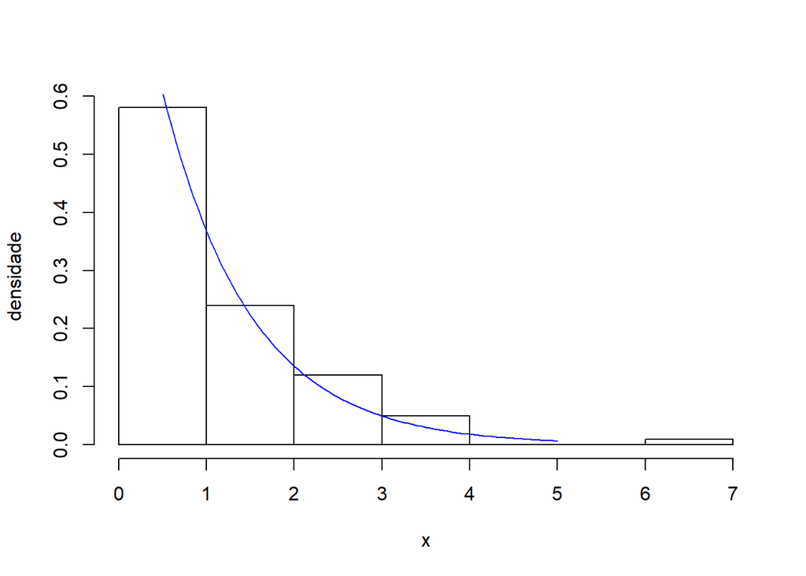

```r
n <- 100
x <- rep(NA,n)
for(i in 1:n){
  x[i] <- -log(runif(1))
}
hist(x,freq=FALSE,xlab="x",ylab="densidade",main="")
points(seq(0,5,0.05),dexp(seq(0,5,0.05),rate=1),type="l",col="blue")
```

Alternativamente, basta fazer

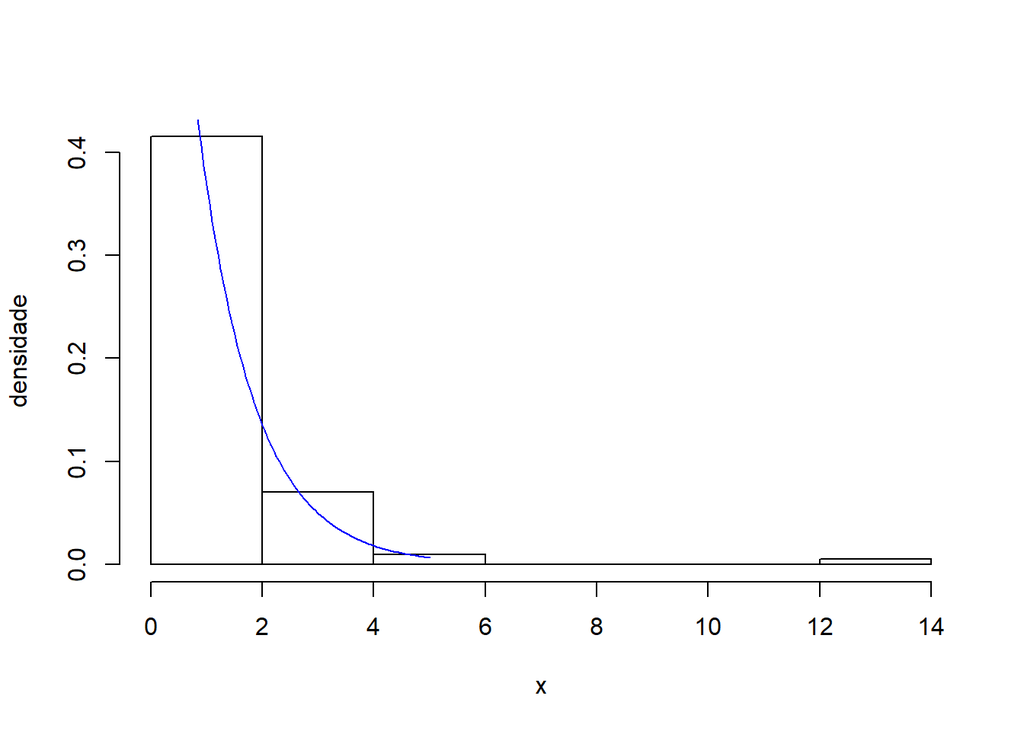

```r
n <- 100
x <- -log(runif(n))
hist(x,freq=FALSE,xlab="x",ylab="densidade",main="")
points(seq(0,5,0.05),dexp(seq(0,5,0.05),rate=1),type="l",col="blue")
```

**Exemplo**. Simule um valor da distribuição $\mbox{Exp}(\lambda)$, onde $\lambda>0$. Sabemos que se $X\sim\mbox{Exp}(1)$, então

$$Y=\frac{1}{\lambda}X\sim\mbox{Exp}(\lambda).$$
Assim, para simular um valor da distribuição $\mbox{Exp}(\lambda)$, basta fazer
$$Y=-\frac{1}{\lambda}\ln(U)$$
onde $U\sim U(0,1)$ é um número aleatório.

## 3.2 Simulação da Distribuição de Erlang

Uma v.a. contínua $X$ possui distribuição de Erlang com parâmetros $k$ (parâmetro de forma) e $\lambda$ (parâmetro de taxa) se sua função densidade de probabilidade é dada por

$$f_{X}(x)=\left\{
\begin{array}{ll}
0 & x < 0 \\
\frac{\lambda^{k}}{k!}x^{k-1}e^{-\lambda x} & x \geq 0
\end{array}
\right.$$
onde $k$ é um inteiro positivo e $\lambda>0$. Além disso, temos que
$$E(X)=\frac{k}{\lambda}\hspace{1cm}V(X)=\frac{k}{\lambda^{2}}.$$
Usamos a notação $X\sim\mbox{Erl}(\lambda)$ para informar que $X$ é uma v.a. com distribuição de Erlang com parâmetros $k$ e $\lambda$. Note que a distribuição de Erlang generaliza a distribuição exponencial e a distribuição gama generaliza a distribuição de Erlang, visto que:
$$\mbox{Exp}(\lambda)\stackrel{D}{=}\mbox{Erl}(k=1,\lambda)$$
e
$$\mbox{Erl}(k,\lambda)\stackrel{D}{=}\mbox{Ga}(\alpha=k,\beta=\lambda).$$
Por fim, note também que
$$Y=\sum_{i=1}^{k}X_{i}\sim\mbox{Erl}(k,\lambda)$$
se $X_{1},\ldots,X_{k}\stackrel{idd}{\sim}\mbox{Exp}(\lambda)$.

**Exemplo**. Simule um valor da distribuição $\mbox{Erl}(k,\lambda)$. Sabendo que $\mbox{Erl}(k,\lambda)$ é igual em distribuição à soma de $k$ exponenciais independentes, todas com taxa $\lambda>0$, então basta fazer

$$Y=\sum_{i=1}^{k}-\frac{1}{\lambda}\ln(U_{i})=-\frac{1}{\lambda}\ln\left(\prod_{i=1}^{k}U_{i}\right)$$
onde $U_{1},\ldots,U_{k}\stackrel{idd}{\sim}U(0,1)$ são $k$ números aleatórios independentes. Vejamos o seguinte exemplo considerando a distribuição $\mbox{Ga}(3,2.3)$:

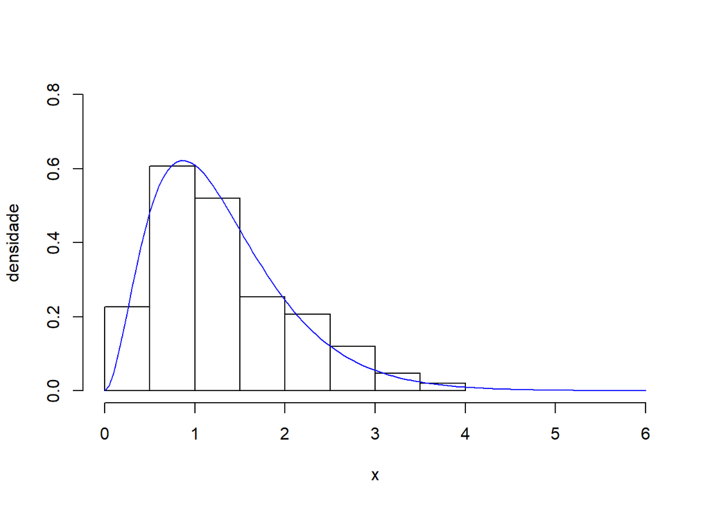

```r
n <- 300;k <- 3;lamb <- 2.3
y <- rep(NA,n)
for(i in 1:n){
  y[i] <- -(1/lamb)*log(prod(runif(k)))
}
hist(y,freq=FALSE,xlim=c(0,6),ylim=c(0,0.8),xlab="x",ylab="densidade",main="")
points(seq(0,6,0.05),dgamma(seq(0,6,0.05),shape=3,rate=2.3),type="l",col="blue")
```

[Voltar ao topo](http://www.maurocampos.com/cursos/estcomp/simulvac.html)

# 4 Simulação da Distribuição Normal Univariada.

Aqui usaremos o **método polar** para simular valores da distribuição normal padrão. Este método é baseado na **transformação Box-Muller**. Antes de entrar em detalhes a respeito deste método, vamos lembrar alguns fatos importantes.

Uma v.a. contínua $X$ possui distribuição normal padrão se sua função densidade de probabilidade é dada por

$$f_{X}(x)=\frac{1}{\sqrt{2\pi}}e^{x^{2}/2}\hspace{1cm}-\infty<x<\infty.$$
É simples verificar que
$$E(X)=0\hspace{1cm}V(X)=1.$$
Além disso, se $-\infty<\mu<\infty$, $\sigma>0$, e $Y=\sigma X + \mu$, então $Y$ possui distribuição normal com média $\mu=E(Y)$ e variância $\sigma^{2}=V(Y)$, e sua função densidade de probabilidade é dada por
$$f_{Y}(y)=f_{X}\left(x=\frac{y-\mu}{\sigma}\right)\left|\frac{dx}{dy}\right|=
\frac{1}{\sqrt{2\pi}\sigma} e^{(y-\mu)^{2}/2\sigma^{2}}\hspace{1cm}-\infty<y<\infty.$$
Usamos a notação $X\sim N(\mu,\sigma^{2})$ para informar que $X$ é uma v.a. com distribuição normal com média $\mu$ e variância $\sigma^{2}$. A normal padrão é denotada por $N(0,1)$.

Outro ponto importante que precisamos lembrar é o método do Jacobiano para encontrar a densidade de um vetor aleatório $\mathbf{Y}=(Y_{1},\ldots,Y_{d})$ contínuo que é função de um outro vetor aleatório contínuo $\mathbf{X}=(X_{1},\ldots,X_{d})$. Considere que $\mathbf{X}\sim f_{\mathbf{X}}$ e seja

$$\begin{array}{ll}
X_{1} & = & X_{1}(Y_{1},\ldots,Y_{d}) \\
\vdots & & \vdots \\
X_{d} & = & X_{d}(Y_{1},\ldots,Y_{d})
\end{array}$$
a representação componente a componente da transformação inversa da transformação $\mathbf{Y}=\mathbf{Y}(\mathbf{X})$, que por sua vez é representada componente a componente tal como segue:
$$\begin{array}{ccc}
Y_{1} & = & Y_{1}(X_{1},\ldots,X_{d}) \\
\vdots & & \vdots \\
Y_{d} & = & Y_{d}(X_{1},\ldots,X_{d}).
\end{array}$$
Então, a densidade de $\mathbf{Y}$ é definida por
$$f_{\mathbf{Y}}(y_{1},\dots,y_{d})=f_{\mathbf{X}}(x_{1}(y_{1},\dots,y_{d}),\ldots,x_{d}(y_{1},\dots,y_{d}))
\cdot\mbox{det}[J(y_{1},\dots,y_{d})]$$
para todo $\mathbf{y}=(y_{1},\dots,y_{d})^{\prime}$ no alcance da transformação $\mathbf{Y}=\mathbf{Y}(\mathbf{X})$, onde $J$ é a matrix Jacobiana da transformação inversa $\mathbf{X}=\mathbf{X}(\mathbf{Y})$. A matrix $J$ é definida por:
$$J(y_{1},\dots,y_{d})=\left(\frac{\partial x_{i}}{\partial y_{j}}\right)_{d\times d}=
\left(
\begin{array}{ccc}
\frac{\partial x_{1}}{\partial y_{1}} & \cdots & \frac{\partial x_{1}}{\partial y_{d}} \\
\vdots & \ddots & \vdots \\
\frac{\partial x_{d}}{\partial y_{1}} & \cdots & \frac{\partial x_{d}}{\partial y_{d}}
\end{array}
\right).$$
Agora estamos em posição de discutir o método polar para simular valores da normal padrão.

Como já informado, o método polar é baseado na transformação Box-Muller, que é definida por:

$$\begin{array}{rcl}
X & = & X(W,\Theta)=\sqrt{W}\cos(\Theta) \\
Y & = & Y(W,\Theta)=\sqrt{W}\sin(\Theta)
\end{array}$$
onde $W\sim\mbox{Exp}(1/2)$ e $\Theta\sim U(0,2\pi)$ são v.a.’s independentes. Consequentemente, a função densidade de probabilidade conjunta de $W$ e $\Theta$ é dada por
$$f_{W,\Theta}(w,\theta)=\frac{1}{2\pi}\cdot\frac{1}{2}e^{-w/2},\hspace{1cm}
0<w<\infty\hspace{1cm}0<\theta<2\pi.$$
Lembrando que a transformação inversa da transformação $(W,\Theta)\mapsto (X,Y)$ é dada por
$$\begin{array}{rcl}
W & = & W(X,Y)=X^{2}+Y^{2} \\
\Theta & = & \Theta(X,Y)=\arctan(Y/X)
\end{array}$$
e usando o método do Jacobiano, segue que
$$f_{X,Y}(x,y)=f_{W,\Theta}(w=x^{2}+y^{2},\theta=\arctan(y/x))\cdot\mbox{det}[J(x,y)]$$
para todo $-\infty<x<+\infty$ e $-\infty<y<+\infty$, onde
$$J(x,y)=
\left(
\begin{array}{cc}
\frac{\partial w}{\partial x} & \frac{\partial w}{\partial y} \\
\frac{\partial \theta}{\partial x} & \frac{\partial \theta}{\partial y}
\end{array}
\right)=
J(x,y)=
\left(
\begin{array}{cc}
2x & 2y \\
-\frac{y}{x^{2}+y^{2}} & \frac{x}{x^{2}+y^{2}}
\end{array}
\right).$$
Assim, como $\mbox{det}[J(x,y)]=2$, segue que
$$f_{X,Y}(x,y)=\frac{1}{2\pi}\cdot\frac{1}{2}e^{-(x^{2}+y^{2})/2}\cdot 2=\frac{1}{2\pi}e^{-(x^{2}+y^{2})/2}$$
de onde se conclui imediatamente que $X\sim N(0,1)$ e $Y\sim N(0,1)$ são v.a.’s independentes.

Portanto, para simular um par de valores da distribuição normal padrão, basta aplicar a transformação Box-Muller

$$\begin{array}{rcl}
X & = & \sqrt{W}\cos(\Theta)=\sqrt{-2\ln(U_{1})}\cos(2\pi\cdot U_{2}) \\
Y & = & \sqrt{W}\sin(\Theta)=\sqrt{-2\ln(U_{1})}\sin(2\pi\cdot U_{2})
\end{array}$$
onde $U_{1}$ e $U_{2}$ são números aleatórios no intervalo $(0,1)$. Lembre-se que $W\sim\mbox{Exp}(1/2)$ e $\Theta\sim U(0,2\pi)$ são simulados como segue:
$$W=-2\ln(U_{1})\hspace{1cm}\Theta=2\pi\cdot U_{2}.$$

O **algoritmo** descrevendo o método polar é dado por:

```
Algoritmo: método polar para simular um par de valores da N(0,1)
  1 Gere números aleatórios, u1 e u2
  2 Calcule w <- -2*log(u1)
  3 Calcule theta <- 2*pi*u2
  4 Calcule x <- sqrt(w)*cos(theta)
  5 Calcule y <- sqrt(w)*sin(theta)
Saída: x,y
```

Vejamos como implementar no R o método polar para simular $n>1$ valores da distribuição $N(0,1)$.

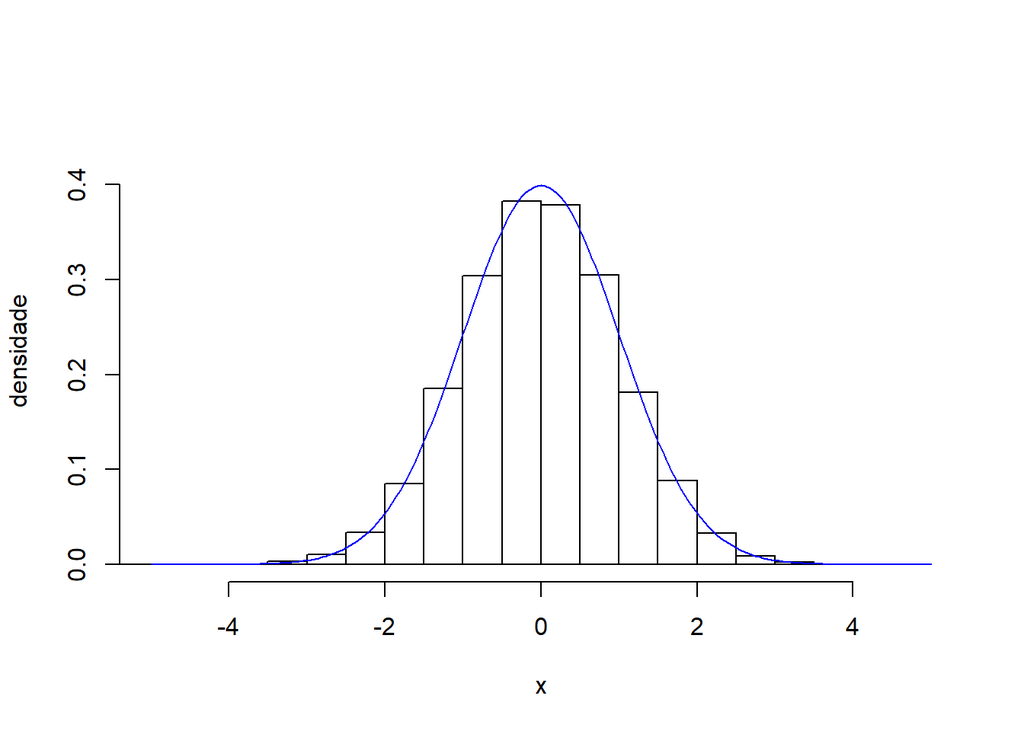

```r
transf.bm <- function(u){
  w <- -2*log(u[1])
  theta <- 2*pi*u[2]
  out <- sqrt(w)*c(cos(theta),sin(theta))
  return(out)
}
n <- 10000; m <- n/2
amostra <- rep(NA,n)
for(i in 1:m){
  j <- 2*i
  amostra[(j-1):j] <- transf.bm(runif(2))
}
1/sqrt(2*pi)
## [1] 0.3989423
hist(amostra,freq=FALSE,xlim=c(-5,5),ylim=c(0,0.45),xlab="x",ylab="densidade",main="")
points(seq(-5,5,0.05),dnorm(seq(-5,5,0.05),mean=0,sd=1),type="l",col="blue")
```

Finalmente, se desejar simular valores de uma v.a. $Y\sim N(\mu,\sigma^{2})$, basta usar a transformação $Y=\sigma X + \mu$, onde $X\sim N(0,1)$. Vejamos agora como implementar no R o método polar para simular $n>1$ valores da distribuição $N(\mu,\sigma^{2})$ quando, por exemplo, $\mu=10$ e $\sigma=\sqrt{2}$.

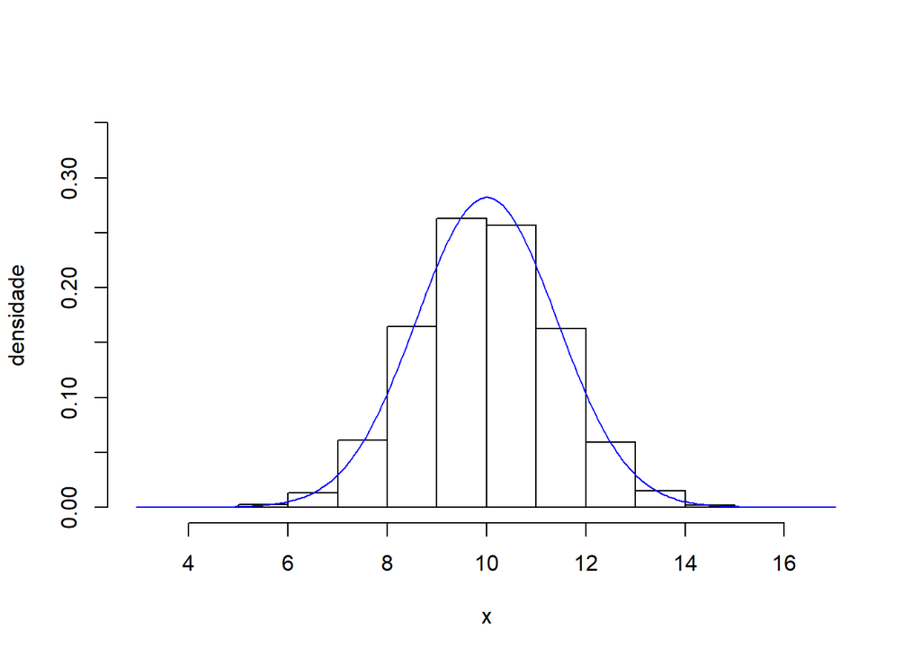

```r
transf.bm <- function(u){
  w <- -2*log(u[1])
  theta <- 2*pi*u[2]
  out <- sqrt(w)*c(cos(theta),sin(theta))
  return(out)
}
na.normalp <- function(n,media,desvio){
  aux <- n%%2
  if(aux==1){nn <- n + 1}else{nn <- n}
  m <- nn/2; out <- rep(NA,nn)
  for(i in 1:m){j <- 2*i; out[(j-1):j] <- transf.bm(runif(2))}
  out <- desvio*out[1:n] + media
  return(out)
}
n <- 9999
m <- 10; dp <- sqrt(2); v <- dp^(2)
amostra <- na.normalp(n,media=m,desvio=dp)
n==length(amostra)
## [1] TRUE
aux1 <- m - 5*dp;aux2 <- m + 5*dp
aux1;aux2;1/sqrt(2*pi*v)
## [1] 2.928932
## [1] 17.07107
## [1] 0.2820948
hist(amostra,freq=FALSE,xlim=c(aux1,aux2),ylim=c(0,0.35),xlab="x",ylab="densidade",main="")
points(seq(aux1,aux2,0.05),dnorm(seq(aux1,aux2,0.05),mean=m,sd=dp),type="l",col="blue")
```

Uma versão mais eficiente do método polar, que evita cálculos de funções trigonométricas, é como segue:

```
Algoritmo: método polar alternativo para simular um par de valores da N(0,1)
  1 Gere dois números aleatórios, u1 e u2
  2 Calcule v1 <- 2*u1 - 1; v2 <- 2*u2 - 1 e s <- v1^(2) + v^(2)
  3 Se S <= 1, então calcule x <- sqrt(-2*log(s)/s)*v1 e y <- sqrt(-2*log(s)/s)*v2. Senão, volte para 1
Saída: x,y
```

[Voltar ao topo](http://www.maurocampos.com/cursos/estcomp/simulvac.html)

# 5 Método da Aceitação e Rejeição

O **método da aceitação e rejeição** já foi discutido para o problema de simular valores de uma v.a. discreta. O método é geral é pode ser aplicado sem modificações para o problema de simular valores de uma v.a. contínua. O **algoritmo** é como segue:

```
Algoritmo: método da aceitação e rejeição
Entrada: f e g # distribuições
  1 Gere um número aleatório y da distribuição g
  2 Gere um número aleatório u
  3 Se u < f(y)/cg(y), então faça x <- y. Caso contrário volte para 1.
Saída: x
```

No caso do método da aceitação e rejeição, lembre-se que o número de iterações que são necessárias para gerar um valor simulado de $f$ é uma variável aleatória com distribuição geométrica com média $c$. Portanto, quanto menor for o valor de $c$ para que $c\cdot g$ envelope $f$, mais eficiente será a simulação.

## 5.1 Simulação da Distribuição Gama

Como já citado, a distribuição gama generaliza a distribuição de Erlang. Uma v.a. contínua $X$ possui distribuição gama com parâmetros $\alpha$ (parâmetro de forma) e $\beta$ (parâmetro de taxa) se sua função densidade de probabilidade é dada por

$$f_{X}(x)=\left\{
\begin{array}{ll}
0 & x < 0 \\
\frac{\beta^{\alpha}}{\Gamma(\alpha)}x^{\alpha-1}e^{-\beta x} & x \geq 0
\end{array}
\right.$$
onde $\alpha,\beta>0$. Além disso, temos que
$$E(X)=\frac{\alpha}{\beta}\hspace{1cm}V(X)=\frac{\alpha}{\beta^{2}}.$$
Usamos a notação $X\sim\mbox{Ga}(\alpha,\beta)$ para informar que $X$ é uma v.a. com distribuição gama com parâmetros $\alpha$ e $\beta$. Note também que $\mbox{Exp}(1)\stackrel{D}{=}\mbox{Ga}(1,1)$. Por fim, o processo de simulação da distribuição gama será discuto em três etapas:

- Simulação da $\mbox{Ga}(\alpha,1)$, quando $\alpha>1$, usando o método da aceitação e rejeição.
- Simulação da $\mbox{Ga}(\alpha,1)$, quando $0<\alpha<1$, usando o fato que $X=YU^{1/\alpha}\sim\mbox{Ga}(\alpha,1)$ se $Y\sim\mbox{Ga}(\alpha+1,1)$ e $U\sim U(0,1)$ são independentes.
- Simulação da $\mbox{Ga}(\alpha,\beta)$, quando $\alpha,\beta>0$, usando o fato que $X=\beta^{-1}Y\sim\mbox{Ga}(\alpha,\beta)$ se $Y\sim\mbox{Ga}(\alpha,1)$.

Resta claro que basta discutir a primeira etapa, pois as outras duas etapas decorrem imediatamente da primeira. Sendo assim, para simular valores da $\mbox{Ga}(\alpha,1)$, quando $\alpha>1$, basta usar o método da aceitação e rejeição, considerando como distribuição auxiliar $g$ a distribuição exponencial com média $\alpha$ (ou seja, no caso a $\mbox{Exp}(\lambda=\alpha^{-1})$), visto que $\alpha$ é também a média da $\mbox{Ga}(\alpha,1)$. É possível mostra que a exponencial com média $\alpha$ é, dentro da classe de modelos exponenciais, a melhor escolha para a distribuição auxiliar, visto que esta distribuição minimiza o valor da constante $c$ que permite que $c\cdot\mbox{Exp}(\alpha^{-1})$ envelope a distribuição $\mbox{Ga}(\alpha,1)$. Neste caso, também é possível mostrar que esta constante $c$ é dada por

$$c=\frac{\alpha^{\alpha}}{\Gamma(\alpha)e^{\alpha-1}}.$$

Portanto, um algoritmo para simular da $\mbox{Ga}(\alpha,1)$, quando $\alpha>1$, é como segue:

```
Algoritmo: método da aceitação e rejeição para simular da Ga(alpha,1)
  1 Gere dois números aleatórios, u1 e u2
  2 Gere y <- -alpha*log(u1) # y é gerado da exponencial com média alpha
  3 Calcule c em função do valor alpha
  4 Se u2 < Ga(y;alpha,1)/c*Exp(y;alpha^(-1)), então x <- y. Caso contrário, volte para 1
Saída: x
```

Vejamos agora como implementar no R este método para simular $n>1$ valores da distribuição $\mbox{Ga}(\alpha,1)$ quando, por exemplo, $\alpha=3/2$.

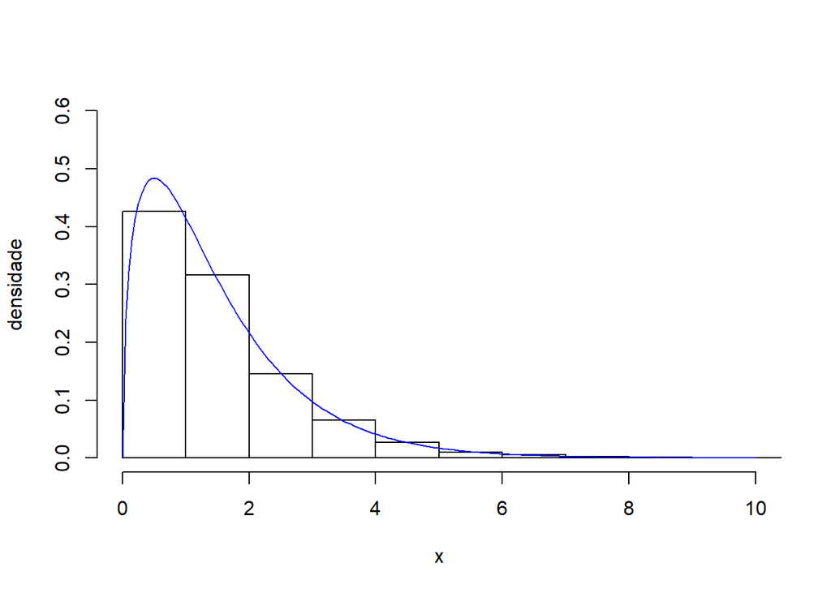

```r
d.exp <- function(x,par.lambda){
  if(x>=0){out <- par.lambda*exp(-par.lambda*x)}else{out <- 0}
  return(out)
}
d.ga <- function(x,par.alpha,par.beta){
  constante <- ((par.beta^(par.alpha))/(gamma(par.alpha)))
  if(x>=0){out <- constante*x^(par.alpha-1)*exp(-par.beta*x)}else{out <- 0}
  return(out)
}
na.ga <- function(par.alpha){
  flag <- 0
  repeat{
   u1 <- runif(1); u2 <- runif(1)
   y <- -par.alpha*log(u1)
   c <- (par.alpha^(par.alpha))/(gamma(par.alpha)*exp(par.alpha-1))
   par.lambda <- 1/par.alpha
   aux <- (d.ga(y,par.alpha,1))/(c*d.exp(y,par.lambda))
   if(u2 < aux){out <- y;flag <- 1}
   if(flag==1){break}
  }
  return(out)
}
na.ga(par.alpha=1.5) # simula um único valor da Ga(1.5,1)
## [1] 0.2591161
#
# Para simular n>1 valores, use um loop
#
n <- 10000
amostra <- rep(NA,n)
for(k in 1:n){amostra[k] <- na.ga(par.alpha=1.5)}
hist(amostra,freq=FALSE,xlim=c(0,10),ylim=c(0,0.6),xlab="x",ylab="densidade",main="")
points(seq(0,10,0.05),dgamma(seq(0,10,0.05),shape=1.5,rate=1.0),type="l",col="blue")
```

## 5.2 Simulação da Distribuição Beta

Uma v.a. contínua $X$ possui distribuição beta com parâmetros $\alpha,\beta>0$ se sua função densidade de probabilidade é dada por

$$f_{X}(x)=\frac{1}{B(\alpha,\beta)}x^{\alpha-1}(1-x)^{\beta-1}\hspace{1cm}0\leq x\leq 1.$$
Além disso
$$E(X)=\frac{\alpha}{\alpha+\beta}\hspace{1cm}V(X)=\frac{\alpha\beta}{(\alpha+\beta)^{2}(\alpha+\beta+1)}.$$

Fica como exercício, mostra que se $X\sim\mbox{Ga}(\alpha,1)$ e $Y\sim\mbox{Ga}(\beta,1)$, então

$$\frac{X}{X+Y}\sim\mbox{Beta}(\alpha,\beta).$$
Este resultado pode ser usado para simular valores da distribuição beta.

[Voltar ao topo](http://www.maurocampos.com/cursos/estcomp/simulvac.html)